# Machine Learning Project: Movies Recommender Systems

ENSAE 2020 - 2021 | Groupe 4 : BRY Nathan et NOKRI Amale

## Libraries import

```python
import pandas as pd
import numpy as np
import re
import json
import math
from scipy.sparse.linalg import svds
import matplotlib.pyplot as plt
import seaborn as sns

from sklearn.feature_extraction.text import TfidfVectorizer
from sklearn.metrics.pairwise import cosine_similarity

import nltk
nltk.download('punkt')
nltk.download('stopwords')
from nltk.corpus import stopwords
from nltk.stem import PorterStemmer
from nltk.tokenize import word_tokenize

from PIL import Image
from wordcloud import WordCloud, STOPWORDS, ImageColorGenerator

import warnings
warnings.filterwarnings('ignore')

sns.set_style('whitegrid')
sns.set(font_scale=1.25)
sns.set()
```

## Loading and exploring the data

#### Ratings

```python
ratings_small = pd.read_csv(r'data_reco\ratings_small.csv') # we load the ratings dataset
ratings_small
```

|  | userId | movieId | rating | timestamp |
| --- | --- | --- | --- | --- |
| 0 | 1 | 31 | 2.5 | 1260759144 |
| 1 | 1 | 1029 | 3.0 | 1260759179 |
| 2 | 1 | 1061 | 3.0 | 1260759182 |
| 3 | 1 | 1129 | 2.0 | 1260759185 |
| 4 | 1 | 1172 | 4.0 | 1260759205 |
| ... | ... | ... | ... | ... |
| 99999 | 671 | 6268 | 2.5 | 1065579370 |
| 100000 | 671 | 6269 | 4.0 | 1065149201 |
| 100001 | 671 | 6365 | 4.0 | 1070940363 |
| 100002 | 671 | 6385 | 2.5 | 1070979663 |
| 100003 | 671 | 6565 | 3.5 | 1074784724 |

100004 rows × 4 columns

```python
c = ratings_small.rating.value_counts()

c.sort_index(ascending=False)
```

```
5.0    15095
4.5     7723
4.0    28750
3.5    10538
3.0    20064
2.5     4449
2.0     7271
1.5     1687
1.0     3326
0.5     1101
Name: rating, dtype: int64
```

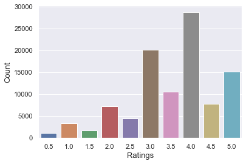

```python
sns.barplot(c.index, c.values)
plt.xlabel('Ratings',size=13)
plt.ylabel('Count',size=13)
plt.show()
```

We can see that the ratings are generally good (about 50% are 4+)!

#### Movies

```python
metadata = pd.read_csv(r'data_reco\movies_metadata.csv') # we load the movies dataset

metadata.head()
```

|  | adult | belongs_to_collection | budget | genres | homepage | id | imdb_id | original_language | original_title | overview | ... | release_date | revenue | runtime | spoken_languages | status | tagline | title | video | vote_average | vote_count |
| --- | --- | --- | --- | --- | --- | --- | --- | --- | --- | --- | --- | --- | --- | --- | --- | --- | --- | --- | --- | --- | --- |
| 0 | False | {'id': 10194, 'name': 'Toy Story Collection', ... | 30000000 | [{'id': 16, 'name': 'Animation'}, {'id': 35, '... | http://toystory.disney.com/toy-story | 862 | tt0114709 | en | Toy Story | Led by Woody, Andy's toys live happily in his ... | ... | 1995-10-30 | 373554033.0 | 81.0 | [{'iso_639_1': 'en', 'name': 'English'}] | Released | NaN | Toy Story | False | 7.7 | 5415.0 |
| 1 | False | NaN | 65000000 | [{'id': 12, 'name': 'Adventure'}, {'id': 14, '... | NaN | 8844 | tt0113497 | en | Jumanji | When siblings Judy and Peter discover an encha... | ... | 1995-12-15 | 262797249.0 | 104.0 | [{'iso_639_1': 'en', 'name': 'English'}, {'iso... | Released | Roll the dice and unleash the excitement! | Jumanji | False | 6.9 | 2413.0 |
| 2 | False | {'id': 119050, 'name': 'Grumpy Old Men Collect... | 0 | [{'id': 10749, 'name': 'Romance'}, {'id': 35, ... | NaN | 15602 | tt0113228 | en | Grumpier Old Men | A family wedding reignites the ancient feud be... | ... | 1995-12-22 | 0.0 | 101.0 | [{'iso_639_1': 'en', 'name': 'English'}] | Released | Still Yelling. Still Fighting. Still Ready for... | Grumpier Old Men | False | 6.5 | 92.0 |
| 3 | False | NaN | 16000000 | [{'id': 35, 'name': 'Comedy'}, {'id': 18, 'nam... | NaN | 31357 | tt0114885 | en | Waiting to Exhale | Cheated on, mistreated and stepped on, the wom... | ... | 1995-12-22 | 81452156.0 | 127.0 | [{'iso_639_1': 'en', 'name': 'English'}] | Released | Friends are the people who let you be yourself... | Waiting to Exhale | False | 6.1 | 34.0 |
| 4 | False | {'id': 96871, 'name': 'Father of the Bride Col... | 0 | [{'id': 35, 'name': 'Comedy'}] | NaN | 11862 | tt0113041 | en | Father of the Bride Part II | Just when George Banks has recovered from his ... | ... | 1995-02-10 | 76578911.0 | 106.0 | [{'iso_639_1': 'en', 'name': 'English'}] | Released | Just When His World Is Back To Normal... He's ... | Father of the Bride Part II | False | 5.7 | 173.0 |

5 rows × 24 columns

```python
movies_df = metadata.drop(['adult','imdb_id','tagline','belongs_to_collection','budget','homepage','poster_path','revenue','runtime','status','video'],1) # we only keep useful columns
movies_df = movies_df.rename(columns={"id": "tmdbId"})

movies_df.head()
```

|  | genres | tmdbId | original_language | original_title | overview | popularity | production_companies | production_countries | release_date | spoken_languages | title | vote_average | vote_count |
| --- | --- | --- | --- | --- | --- | --- | --- | --- | --- | --- | --- | --- | --- |
| 0 | [{'id': 16, 'name': 'Animation'}, {'id': 35, '... | 862 | en | Toy Story | Led by Woody, Andy's toys live happily in his ... | 21.9469 | [{'name': 'Pixar Animation Studios', 'id': 3}] | [{'iso_3166_1': 'US', 'name': 'United States o... | 1995-10-30 | [{'iso_639_1': 'en', 'name': 'English'}] | Toy Story | 7.7 | 5415.0 |
| 1 | [{'id': 12, 'name': 'Adventure'}, {'id': 14, '... | 8844 | en | Jumanji | When siblings Judy and Peter discover an encha... | 17.0155 | [{'name': 'TriStar Pictures', 'id': 559}, {'na... | [{'iso_3166_1': 'US', 'name': 'United States o... | 1995-12-15 | [{'iso_639_1': 'en', 'name': 'English'}, {'iso... | Jumanji | 6.9 | 2413.0 |
| 2 | [{'id': 10749, 'name': 'Romance'}, {'id': 35, ... | 15602 | en | Grumpier Old Men | A family wedding reignites the ancient feud be... | 11.7129 | [{'name': 'Warner Bros.', 'id': 6194}, {'name'... | [{'iso_3166_1': 'US', 'name': 'United States o... | 1995-12-22 | [{'iso_639_1': 'en', 'name': 'English'}] | Grumpier Old Men | 6.5 | 92.0 |
| 3 | [{'id': 35, 'name': 'Comedy'}, {'id': 18, 'nam... | 31357 | en | Waiting to Exhale | Cheated on, mistreated and stepped on, the wom... | 3.85949 | [{'name': 'Twentieth Century Fox Film Corporat... | [{'iso_3166_1': 'US', 'name': 'United States o... | 1995-12-22 | [{'iso_639_1': 'en', 'name': 'English'}] | Waiting to Exhale | 6.1 | 34.0 |
| 4 | [{'id': 35, 'name': 'Comedy'}] | 11862 | en | Father of the Bride Part II | Just when George Banks has recovered from his ... | 8.38752 | [{'name': 'Sandollar Productions', 'id': 5842}... | [{'iso_3166_1': 'US', 'name': 'United States o... | 1995-02-10 | [{'iso_639_1': 'en', 'name': 'English'}] | Father of the Bride Part II | 5.7 | 173.0 |

```python
# we load the links dataset (we need to use it to join the ratings and movies dataframes with movieId)

links_small = pd.read_csv(r'data_reco\links_small.csv')
```

```python
links_small = links_small.dropna() #drop null values to avoid errors

links_small['tmdbId'] = links_small['tmdbId'].astype(int).astype(str) #convert data type

reduced_movies_df = pd.merge(movies_df,links_small,on='tmdbId') #merge the 2 dataframes
```

```python
reduced_movies_df
```

|  | genres | tmdbId | original_language | original_title | overview | popularity | production_companies | production_countries | release_date | spoken_languages | title | vote_average | vote_count | movieId | imdbId |
| --- | --- | --- | --- | --- | --- | --- | --- | --- | --- | --- | --- | --- | --- | --- | --- |
| 0 | [{'id': 16, 'name': 'Animation'}, {'id': 35, '... | 862 | en | Toy Story | Led by Woody, Andy's toys live happily in his ... | 21.9469 | [{'name': 'Pixar Animation Studios', 'id': 3}] | [{'iso_3166_1': 'US', 'name': 'United States o... | 1995-10-30 | [{'iso_639_1': 'en', 'name': 'English'}] | Toy Story | 7.7 | 5415.0 | 1 | 114709 |
| 1 | [{'id': 12, 'name': 'Adventure'}, {'id': 14, '... | 8844 | en | Jumanji | When siblings Judy and Peter discover an encha... | 17.0155 | [{'name': 'TriStar Pictures', 'id': 559}, {'na... | [{'iso_3166_1': 'US', 'name': 'United States o... | 1995-12-15 | [{'iso_639_1': 'en', 'name': 'English'}, {'iso... | Jumanji | 6.9 | 2413.0 | 2 | 113497 |
| 2 | [{'id': 10749, 'name': 'Romance'}, {'id': 35, ... | 15602 | en | Grumpier Old Men | A family wedding reignites the ancient feud be... | 11.7129 | [{'name': 'Warner Bros.', 'id': 6194}, {'name'... | [{'iso_3166_1': 'US', 'name': 'United States o... | 1995-12-22 | [{'iso_639_1': 'en', 'name': 'English'}] | Grumpier Old Men | 6.5 | 92.0 | 3 | 113228 |
| 3 | [{'id': 35, 'name': 'Comedy'}, {'id': 18, 'nam... | 31357 | en | Waiting to Exhale | Cheated on, mistreated and stepped on, the wom... | 3.85949 | [{'name': 'Twentieth Century Fox Film Corporat... | [{'iso_3166_1': 'US', 'name': 'United States o... | 1995-12-22 | [{'iso_639_1': 'en', 'name': 'English'}] | Waiting to Exhale | 6.1 | 34.0 | 4 | 114885 |
| 4 | [{'id': 35, 'name': 'Comedy'}] | 11862 | en | Father of the Bride Part II | Just when George Banks has recovered from his ... | 8.38752 | [{'name': 'Sandollar Productions', 'id': 5842}... | [{'iso_3166_1': 'US', 'name': 'United States o... | 1995-02-10 | [{'iso_639_1': 'en', 'name': 'English'}] | Father of the Bride Part II | 5.7 | 173.0 | 5 | 113041 |
| ... | ... | ... | ... | ... | ... | ... | ... | ... | ... | ... | ... | ... | ... | ... | ... |
| 9094 | [{'id': 18, 'name': 'Drama'}] | 159550 | en | The Last Brickmaker in America | A man must cope with the loss of his wife and ... | 0.038998 | [{'name': 'Nasser Entertainment', 'id': 35802}] | [{'iso_3166_1': 'US', 'name': 'United States o... | 2001-09-23 | [] | The Last Brickmaker in America | 7.0 | 1.0 | 161944 | 255313 |
| 9095 | [{'id': 53, 'name': 'Thriller'}, {'id': 10749,... | 392572 | hi | रुस्तम | Rustom Pavri, an honourable officer of the Ind... | 7.333139 | [{'name': 'KriArj Entertainment', 'id': 91689}] | [{'iso_3166_1': 'IN', 'name': 'India'}] | 2016-08-12 | [{'iso_639_1': 'hi', 'name': 'हिन्दी'}] | Rustom | 7.3 | 25.0 | 162542 | 5165344 |
| 9096 | [{'id': 12, 'name': 'Adventure'}, {'id': 18, '... | 402672 | hi | Mohenjo Daro | Village lad Sarman is drawn to big, bad Mohenj... | 1.423358 | [{'name': 'UTV Motion Pictures', 'id': 2320}, ... | [{'iso_3166_1': 'IN', 'name': 'India'}] | 2016-08-11 | [{'iso_639_1': 'hi', 'name': 'हिन्दी'}] | Mohenjo Daro | 6.7 | 26.0 | 162672 | 3859980 |
| 9097 | [{'id': 28, 'name': 'Action'}, {'id': 12, 'nam... | 315011 | ja | シン・ゴジラ | From the mind behind Evangelion comes a hit la... | 9.285519 | [{'name': 'Cine Bazar', 'id': 5896}, {'name': ... | [{'iso_3166_1': 'JP', 'name': 'Japan'}] | 2016-07-29 | [{'iso_639_1': 'it', 'name': 'Italiano'}, {'is... | Shin Godzilla | 6.6 | 152.0 | 163056 | 4262980 |
| 9098 | [{'id': 99, 'name': 'Documentary'}, {'id': 104... | 391698 | en | The Beatles: Eight Days a Week - The Touring Y... | The band stormed Europe in 1963, and, in 1964,... | 7.078301 | [{'name': 'Imagine Entertainment', 'id': 23}, ... | [{'iso_3166_1': 'GB', 'name': 'United Kingdom'... | 2016-09-15 | [{'iso_639_1': 'en', 'name': 'English'}] | The Beatles: Eight Days a Week - The Touring Y... | 7.6 | 92.0 | 163949 | 2531318 |

9099 rows × 15 columns

Now that we have reduced our data to 100000 ratings from 671 users on 9100 movies, let's have a closer look at our data. As we can see, the genres column currently is a list of genres dictionnaries. Let's work on it to get something easier to read

```python
genres_list = reduced_movies_df.genres.to_list()
```

```python
final_genres_list = []

for movie in genres_list:
    lst = [v for i, v in enumerate(movie.split(",")) if i % 2 == 1]

    mid_genres_lst = []
    for i in lst:

        result = re.search('\'name\': \'(.*)\'', i)
        if result is not None:

            mid_genres_lst.append(result.group(1))

    final_genres_list.append(' - '.join(mid_genres_lst))
```

```python
reduced_movies_df['genres'] = final_genres_list
reduced_movies_df.head()

# We now have something much easier to read!
```

|  | genres | tmdbId | original_language | original_title | overview | popularity | production_companies | production_countries | release_date | spoken_languages | title | vote_average | vote_count | movieId | imdbId |
| --- | --- | --- | --- | --- | --- | --- | --- | --- | --- | --- | --- | --- | --- | --- | --- |
| 0 | Animation - Comedy - Family | 862 | en | Toy Story | Led by Woody, Andy's toys live happily in his ... | 21.9469 | [{'name': 'Pixar Animation Studios', 'id': 3}] | [{'iso_3166_1': 'US', 'name': 'United States o... | 1995-10-30 | [{'iso_639_1': 'en', 'name': 'English'}] | Toy Story | 7.7 | 5415.0 | 1 | 114709 |
| 1 | Adventure - Fantasy - Family | 8844 | en | Jumanji | When siblings Judy and Peter discover an encha... | 17.0155 | [{'name': 'TriStar Pictures', 'id': 559}, {'na... | [{'iso_3166_1': 'US', 'name': 'United States o... | 1995-12-15 | [{'iso_639_1': 'en', 'name': 'English'}, {'iso... | Jumanji | 6.9 | 2413.0 | 2 | 113497 |
| 2 | Romance - Comedy | 15602 | en | Grumpier Old Men | A family wedding reignites the ancient feud be... | 11.7129 | [{'name': 'Warner Bros.', 'id': 6194}, {'name'... | [{'iso_3166_1': 'US', 'name': 'United States o... | 1995-12-22 | [{'iso_639_1': 'en', 'name': 'English'}] | Grumpier Old Men | 6.5 | 92.0 | 3 | 113228 |
| 3 | Comedy - Drama - Romance | 31357 | en | Waiting to Exhale | Cheated on, mistreated and stepped on, the wom... | 3.85949 | [{'name': 'Twentieth Century Fox Film Corporat... | [{'iso_3166_1': 'US', 'name': 'United States o... | 1995-12-22 | [{'iso_639_1': 'en', 'name': 'English'}] | Waiting to Exhale | 6.1 | 34.0 | 4 | 114885 |
| 4 | Comedy | 11862 | en | Father of the Bride Part II | Just when George Banks has recovered from his ... | 8.38752 | [{'name': 'Sandollar Productions', 'id': 5842}... | [{'iso_3166_1': 'US', 'name': 'United States o... | 1995-02-10 | [{'iso_639_1': 'en', 'name': 'English'}] | Father of the Bride Part II | 5.7 | 173.0 | 5 | 113041 |

```python
# Let's make a of all genres to count them

list_genres = []

for i in final_genres_list:
    if i != '':
        list_genres += i.split(' - ')
```

```python
genres = pd.Series(list_genres).value_counts()

genres
```

```
Drama              4659
Comedy             3379
Thriller           2019
Romance            1852
Action             1755
Crime              1257
Adventure          1201
Horror              918
Science Fiction     862
Family              861
Fantasy             752
Mystery             651
Documentary         463
Music               452
Animation           444
History             344
War                 272
Western             172
Foreign             106
TV Movie             37
dtype: int64
```

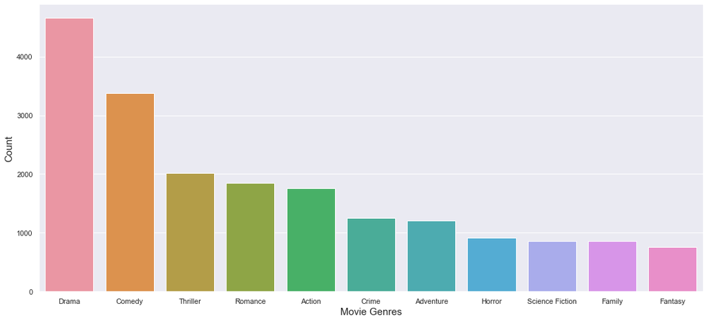

```python
plt.figure(figsize=(18,8))
sns.barplot(genres[:11].index, genres[:11].values)
plt.xlabel('Movie Genres',size=15)
plt.ylabel('Count',size=15)
plt.show()
```

As we have about 9000 movies, we can see that 50% of them are Dramas, and one third are Comedies. The Thriller, Romance and Action genres are also well represented (around 20% for each)

```python
# Let's now have a look at our overviews

overviews_list = reduced_movies_df.overview.to_list()
```

```python
# First, we need to apply NLP techniques (like removing stopword and punctuation, and stemming all words)
# to transform our overviews se we can analyze them

# So let's create our preprocessing function

def preprocess(string):

    #Remove punctuation and lower all characters
    words = nltk.word_tokenize(string)
    words = [word.lower() for word in words if word.isalnum()]
#     print(words)

    #Remove stop words
    stop_words = set(stopwords.words('english'))
    words2 = [i for i in words if not i in stop_words]
#     print(words2)

    #Stemming
    stemmer = PorterStemmer()
    final = [stemmer.stem(word) for word in words2]
#     print(final)

    return final
```

```python
# Let's apply the function to our overviews and store the new ones in our dataframe

preprocessed_overviews = [preprocess(str(overview)) for overview in overviews_list]
reduced_movies_df['preprocessed_overview'] = preprocessed_overviews

preprocessed_overviews_concat = [" ".join(overview) for overview in preprocessed_overviews]
reduced_movies_df['concat_preprocessed_overview'] = preprocessed_overviews_concat
```

```python
# Here we create a string containing all the preprocessed overviews, to later create a beautiful word cloud

concat_overviews = ""

for overview in preprocessed_overviews:
    concat_overviews = concat_overviews + " " + " ".join(overview)

concat_overviews = concat_overviews.lstrip()
```

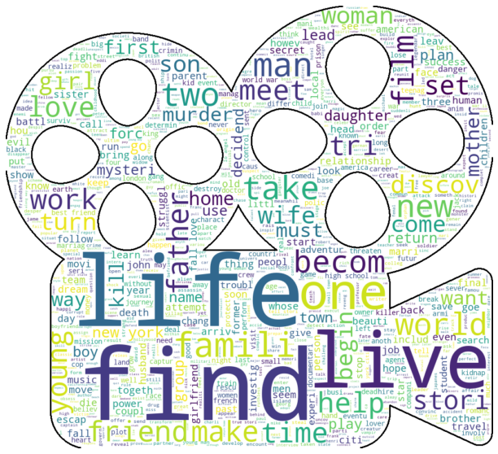

```python
# And here we generate our word cloud, on a cinema logo background!

movie_mask = np.array(Image.open("movie_icon.png"))

wc = WordCloud(background_color="white", max_words=1000, mask=movie_mask, contour_width=3)

wc.generate(concat_overviews)

plt.figure(figsize=[20,10])
plt.imshow(wc, interpolation='bilinear')
plt.axis("off")
plt.show()
```

As we can see the most popular (frequent) words are things like "find", "live", "life" which might refer to movies were the heroes are looking for something that will change their daily life. We also see words like "friend", "famili" and "love" that probably refer to Dramas or Comedies!

## Collaborative Filtering: SVD

Now that we've had a look at our data, let's create our first recommender system. We will start with Collaborative Filtering and perform Singular Values Decomposition (SVD).

```python
# we create the user-movie matrix, where rows are users, movies are columns and values are the ratings

ratings_matrix = ratings_small.pivot(index = 'userId', columns ='movieId', values = 'rating').fillna(0)
ratings_matrix
```

| movieId userId | 1 | 2 | 3 | 4 | 5 | 6 | 7 | 8 | 9 | 10 | ... | 161084 | 161155 | 161594 | 161830 | 161918 | 161944 | 162376 | 162542 | 162672 | 163949 |
| --- | --- | --- | --- | --- | --- | --- | --- | --- | --- | --- | --- | --- | --- | --- | --- | --- | --- | --- | --- | --- | --- |
| 1 | 0.0 | 0.0 | 0.0 | 0.0 | 0.0 | 0.0 | 0.0 | 0.0 | 0.0 | 0.0 | ... | 0.0 | 0.0 | 0.0 | 0.0 | 0.0 | 0.0 | 0.0 | 0.0 | 0.0 | 0.0 |
| 2 | 0.0 | 0.0 | 0.0 | 0.0 | 0.0 | 0.0 | 0.0 | 0.0 | 0.0 | 4.0 | ... | 0.0 | 0.0 | 0.0 | 0.0 | 0.0 | 0.0 | 0.0 | 0.0 | 0.0 | 0.0 |
| 3 | 0.0 | 0.0 | 0.0 | 0.0 | 0.0 | 0.0 | 0.0 | 0.0 | 0.0 | 0.0 | ... | 0.0 | 0.0 | 0.0 | 0.0 | 0.0 | 0.0 | 0.0 | 0.0 | 0.0 | 0.0 |
| 4 | 0.0 | 0.0 | 0.0 | 0.0 | 0.0 | 0.0 | 0.0 | 0.0 | 0.0 | 4.0 | ... | 0.0 | 0.0 | 0.0 | 0.0 | 0.0 | 0.0 | 0.0 | 0.0 | 0.0 | 0.0 |
| 5 | 0.0 | 0.0 | 4.0 | 0.0 | 0.0 | 0.0 | 0.0 | 0.0 | 0.0 | 0.0 | ... | 0.0 | 0.0 | 0.0 | 0.0 | 0.0 | 0.0 | 0.0 | 0.0 | 0.0 | 0.0 |
| ... | ... | ... | ... | ... | ... | ... | ... | ... | ... | ... | ... | ... | ... | ... | ... | ... | ... | ... | ... | ... | ... |
| 667 | 0.0 | 0.0 | 0.0 | 0.0 | 0.0 | 4.0 | 0.0 | 0.0 | 0.0 | 0.0 | ... | 0.0 | 0.0 | 0.0 | 0.0 | 0.0 | 0.0 | 0.0 | 0.0 | 0.0 | 0.0 |
| 668 | 0.0 | 0.0 | 0.0 | 0.0 | 0.0 | 0.0 | 0.0 | 0.0 | 0.0 | 0.0 | ... | 0.0 | 0.0 | 0.0 | 0.0 | 0.0 | 0.0 | 0.0 | 0.0 | 0.0 | 0.0 |
| 669 | 0.0 | 0.0 | 0.0 | 0.0 | 0.0 | 0.0 | 0.0 | 0.0 | 0.0 | 0.0 | ... | 0.0 | 0.0 | 0.0 | 0.0 | 0.0 | 0.0 | 0.0 | 0.0 | 0.0 | 0.0 |
| 670 | 4.0 | 0.0 | 0.0 | 0.0 | 0.0 | 0.0 | 0.0 | 0.0 | 0.0 | 0.0 | ... | 0.0 | 0.0 | 0.0 | 0.0 | 0.0 | 0.0 | 0.0 | 0.0 | 0.0 | 0.0 |
| 671 | 5.0 | 0.0 | 0.0 | 0.0 | 0.0 | 0.0 | 0.0 | 0.0 | 0.0 | 0.0 | ... | 0.0 | 0.0 | 0.0 | 0.0 | 0.0 | 0.0 | 0.0 | 0.0 | 0.0 | 0.0 |

671 rows × 9066 columns

```python
ratings = ratings_matrix.values # we convert to dataframe to a numpy array

# here we do the singular value decomposition using the scipy library
# k is the number of latent factors (variables latentes) that we use to use to approximate the original ratings matrix
U, sigma, Vt = svds(ratings, k = 50)

# as the sigma returned is just the values instead of a diagonal matrix, we convert it to the diagonal matrix form
sigma = np.diag(sigma)

# we now make the movie ratings predictions for every user, by doing the matrix multiplication of U, sigma and Vt
all_user_predicted_ratings = np.dot(np.dot(U, sigma), Vt)

# we convert the predictions to a dataframe
predictions = pd.DataFrame(all_user_predicted_ratings, columns = ratings_matrix.columns)
```

```python
predictions
```

| movieId | 1 | 2 | 3 | 4 | 5 | 6 | 7 | 8 | 9 | 10 | ... | 161084 | 161155 | 161594 | 161830 | 161918 | 161944 | 162376 | 162542 | 162672 | 163949 |
| --- | --- | --- | --- | --- | --- | --- | --- | --- | --- | --- | --- | --- | --- | --- | --- | --- | --- | --- | --- | --- | --- |
| 0 | -0.057419 | 0.044156 | -0.003525 | -0.014026 | -0.011693 | 0.037647 | -0.011436 | -0.012794 | 0.017412 | 0.037456 | ... | -0.001519 | 0.000171 | 0.016497 | 0.000130 | 0.000195 | -0.013686 | 0.024746 | -0.000700 | -0.000420 | -0.003038 |
| 1 | 0.397099 | 1.422453 | -0.175735 | 0.166606 | 0.269432 | 0.385791 | 0.068086 | 0.043673 | -0.004759 | 2.241940 | ... | -0.002005 | 0.000998 | -0.007596 | 0.000552 | 0.000828 | -0.059196 | -0.011395 | 0.005804 | 0.003482 | -0.004010 |
| 2 | 1.275403 | 0.296807 | 0.033442 | -0.010834 | 0.100854 | 0.062972 | -0.088911 | 0.009645 | -0.002955 | 0.227495 | ... | -0.002610 | -0.004553 | -0.011604 | 0.000279 | 0.000419 | -0.008031 | -0.017406 | 0.008379 | 0.005027 | -0.005219 |
| 3 | 1.183095 | 1.016435 | 0.105598 | 0.074721 | -0.337196 | -1.433923 | -0.337587 | -0.154619 | -0.056599 | 1.551431 | ... | 0.023616 | 0.008438 | 0.058714 | 0.003375 | 0.005062 | 0.150868 | 0.088071 | -0.023062 | -0.013837 | 0.047233 |
| 4 | 1.338518 | 1.510306 | 0.655975 | -0.030616 | 0.764755 | -0.159291 | 0.009004 | 0.054437 | -0.134904 | 0.396755 | ... | 0.001700 | -0.000225 | 0.016028 | 0.006308 | 0.009463 | -0.005235 | 0.024042 | 0.013163 | 0.007898 | 0.003400 |
| ... | ... | ... | ... | ... | ... | ... | ... | ... | ... | ... | ... | ... | ... | ... | ... | ... | ... | ... | ... | ... | ... |
| 666 | 1.401178 | 0.822743 | 0.374469 | 0.133373 | 0.362945 | 1.472716 | 0.569492 | -0.005158 | 0.212045 | 1.418073 | ... | 0.001038 | 0.000516 | 0.006303 | 0.004665 | 0.006997 | -0.030318 | 0.009454 | 0.003316 | 0.001990 | 0.002076 |
| 667 | 0.572494 | -0.220032 | -0.042970 | 0.002644 | 0.003999 | 0.325578 | -0.123410 | -0.044693 | 0.000918 | -0.009656 | ... | 0.001195 | -0.002391 | -0.005450 | 0.003808 | 0.005712 | -0.015223 | -0.008175 | -0.005560 | -0.003336 | 0.002390 |
| 668 | 0.700155 | -0.123180 | 0.205792 | 0.032453 | -0.011939 | 0.225335 | 0.013773 | -0.005908 | 0.134283 | 0.060317 | ... | -0.002819 | -0.001373 | -0.002525 | 0.000562 | 0.000844 | 0.017333 | -0.003788 | 0.004294 | 0.002576 | -0.005638 |
| 669 | 1.574291 | 0.089282 | -0.037597 | -0.035669 | 0.194547 | 0.755806 | 0.001511 | -0.020185 | -0.028840 | 0.261701 | ... | 0.001215 | -0.000247 | 0.006292 | 0.002198 | 0.003296 | -0.041420 | 0.009439 | 0.001356 | 0.000814 | 0.002430 |
| 670 | 3.596517 | 0.277681 | -0.117446 | 0.154601 | -0.031039 | -0.223173 | 0.112561 | 0.059964 | -0.388022 | -0.017336 | ... | -0.009228 | -0.009042 | -0.001273 | -0.006460 | -0.009691 | 0.091067 | -0.001909 | 0.005612 | 0.003367 | -0.018457 |

671 rows × 9066 columns

```python
# we rename the index and make it start from one to match the user ids

predictions.index.name = 'userId'
predictions.index += 1

predictions
```

| movieId userId | 1 | 2 | 3 | 4 | 5 | 6 | 7 | 8 | 9 | 10 | ... | 161084 | 161155 | 161594 | 161830 | 161918 | 161944 | 162376 | 162542 | 162672 | 163949 |
| --- | --- | --- | --- | --- | --- | --- | --- | --- | --- | --- | --- | --- | --- | --- | --- | --- | --- | --- | --- | --- | --- |
| 1 | -0.057419 | 0.044156 | -0.003525 | -0.014026 | -0.011693 | 0.037647 | -0.011436 | -0.012794 | 0.017412 | 0.037456 | ... | -0.001519 | 0.000171 | 0.016497 | 0.000130 | 0.000195 | -0.013686 | 0.024746 | -0.000700 | -0.000420 | -0.003038 |
| 2 | 0.397099 | 1.422453 | -0.175735 | 0.166606 | 0.269432 | 0.385791 | 0.068086 | 0.043673 | -0.004759 | 2.241940 | ... | -0.002005 | 0.000998 | -0.007596 | 0.000552 | 0.000828 | -0.059196 | -0.011395 | 0.005804 | 0.003482 | -0.004010 |
| 3 | 1.275403 | 0.296807 | 0.033442 | -0.010834 | 0.100854 | 0.062972 | -0.088911 | 0.009645 | -0.002955 | 0.227495 | ... | -0.002610 | -0.004553 | -0.011604 | 0.000279 | 0.000419 | -0.008031 | -0.017406 | 0.008379 | 0.005027 | -0.005219 |
| 4 | 1.183095 | 1.016435 | 0.105598 | 0.074721 | -0.337196 | -1.433923 | -0.337587 | -0.154619 | -0.056599 | 1.551431 | ... | 0.023616 | 0.008438 | 0.058714 | 0.003375 | 0.005062 | 0.150868 | 0.088071 | -0.023062 | -0.013837 | 0.047233 |
| 5 | 1.338518 | 1.510306 | 0.655975 | -0.030616 | 0.764755 | -0.159291 | 0.009004 | 0.054437 | -0.134904 | 0.396755 | ... | 0.001700 | -0.000225 | 0.016028 | 0.006308 | 0.009463 | -0.005235 | 0.024042 | 0.013163 | 0.007898 | 0.003400 |
| ... | ... | ... | ... | ... | ... | ... | ... | ... | ... | ... | ... | ... | ... | ... | ... | ... | ... | ... | ... | ... | ... |
| 667 | 1.401178 | 0.822743 | 0.374469 | 0.133373 | 0.362945 | 1.472716 | 0.569492 | -0.005158 | 0.212045 | 1.418073 | ... | 0.001038 | 0.000516 | 0.006303 | 0.004665 | 0.006997 | -0.030318 | 0.009454 | 0.003316 | 0.001990 | 0.002076 |
| 668 | 0.572494 | -0.220032 | -0.042970 | 0.002644 | 0.003999 | 0.325578 | -0.123410 | -0.044693 | 0.000918 | -0.009656 | ... | 0.001195 | -0.002391 | -0.005450 | 0.003808 | 0.005712 | -0.015223 | -0.008175 | -0.005560 | -0.003336 | 0.002390 |
| 669 | 0.700155 | -0.123180 | 0.205792 | 0.032453 | -0.011939 | 0.225335 | 0.013773 | -0.005908 | 0.134283 | 0.060317 | ... | -0.002819 | -0.001373 | -0.002525 | 0.000562 | 0.000844 | 0.017333 | -0.003788 | 0.004294 | 0.002576 | -0.005638 |
| 670 | 1.574291 | 0.089282 | -0.037597 | -0.035669 | 0.194547 | 0.755806 | 0.001511 | -0.020185 | -0.028840 | 0.261701 | ... | 0.001215 | -0.000247 | 0.006292 | 0.002198 | 0.003296 | -0.041420 | 0.009439 | 0.001356 | 0.000814 | 0.002430 |
| 671 | 3.596517 | 0.277681 | -0.117446 | 0.154601 | -0.031039 | -0.223173 | 0.112561 | 0.059964 | -0.388022 | -0.017336 | ... | -0.009228 | -0.009042 | -0.001273 | -0.006460 | -0.009691 | 0.091067 | -0.001909 | 0.005612 | 0.003367 | -0.018457 |

671 rows × 9066 columns

```python
# We create our function that will make movies recommendations

def movies_recommender1(user_id, nb_recommendations=5):

    # Get and sort the user's predictions
    sorted_user_predictions = predictions.iloc[user_id].sort_values(ascending=False).rename("Predictions")

    # Get the user's data and merge in the movie information
    user_data = ratings_small[ratings_small.userId == user_id]
    user_full = (user_data.merge(reduced_movies_df, how = 'left', left_on = 'movieId', right_on = 'movieId').
                     sort_values(['rating'], ascending=False)
                 )[['movieId','title','rating','genres']]

    print('User {0} has already rated {1} movies.'.format(user_id, user_full.shape[0]))
    print('Recommending highest {0} predicted ratings movies not already rated.'.format(nb_recommendations))

    # Recommend the highest predicted rating movies that the user hasn't seen yet
    recommendations = (reduced_movies_df[~reduced_movies_df['movieId'].isin(user_full['movieId'])].
         merge(pd.DataFrame(sorted_user_predictions).reset_index(), how = 'left',
               left_on = 'movieId',
               right_on = 'movieId').
         sort_values('Predictions', ascending = False).
                       iloc[:nb_recommendations, :-1]
                      )[['title','genres']]

    return user_full, recommendations
```

```python
already_rated, recommended_movies = movies_recommender1(6,10)
```

```
User 6 has already rated 44 movies.
Recommending highest 10 predicted ratings movies not already rated.
```

```python
# Here we can see the 20 top rated movies by our test user

already_rated[:20]
```

|  | movieId | title | rating | genres |
| --- | --- | --- | --- | --- |
| 3 | 293 | Leon: The Professional | 5.0 | Thriller - Crime - Drama |
| 36 | 5952 | The Lord of the Rings: The Two Towers | 5.0 | Adventure - Fantasy - Action |
| 38 | 7153 | The Lord of the Rings: The Return of the King | 5.0 | Adventure - Fantasy - Action |
| 6 | 1204 | Lawrence of Arabia | 5.0 | Adventure - Drama - History - War |
| 43 | 8874 | Shaun of the Dead | 4.5 | Horror - Comedy |
| 8 | 1259 | Stand by Me | 4.5 | Crime - Drama |
| 28 | 2761 | The Iron Giant | 4.5 | Adventure - Animation - Family - Fantasy - Sci... |
| 10 | 1285 | Heathers | 4.5 | Thriller - Comedy - Drama |
| 9 | 1276 | Cool Hand Luke | 4.5 | Crime - Drama |
| 7 | 1250 | The Bridge on the River Kwai | 4.5 | Drama - History - War |
| 18 | 2019 | Seven Samurai | 4.0 | Action - Drama |
| 39 | 7361 | Eternal Sunshine of the Spotless Mind | 4.0 | Science Fiction - Drama - Romance |
| 31 | 3114 | Toy Story 2 | 4.0 | Animation - Comedy - Family |
| 41 | 8636 | Spider-Man 2 | 4.0 | Action - Adventure - Fantasy |
| 26 | 2692 | Run Lola Run | 4.0 | Action - Drama - Thriller |
| 23 | 2529 | Planet of the Apes | 4.0 | Science Fiction - Adventure - Drama - Action |
| 20 | 2174 | Beetlejuice | 4.0 | Fantasy - Comedy |
| 19 | 2072 | The 'Burbs | 4.0 | Comedy - Horror - Thriller |
| 0 | 111 | Taxi Driver | 4.0 | Crime - Drama |
| 4 | 596 | Pinocchio | 4.0 | Animation - Family |

```python
# and here we have the top 10 recommendations made by our function!

recommended_movies
```

|  | title | genres |
| --- | --- | --- |
| 229 | Star Wars | Adventure - Action - Science Fiction |
| 946 | The Empire Strikes Back | Adventure - Action - Science Fiction |
| 958 | Return of the Jedi | Adventure - Action - Science Fiction |
| 317 | Forrest Gump | Comedy - Drama - Romance |
| 948 | Raiders of the Lost Ark | Adventure - Action |
| 518 | Terminator 2: Judgment Day | Action - Thriller - Science Fiction |
| 423 | Jurassic Park | Adventure - Science Fiction |
| 100 | Braveheart | Action - Drama - History - War |
| 947 | The Princess Bride | Adventure - Family - Fantasy - Comedy - Romance |
| 1014 | Back to the Future | Adventure - Comedy - Science Fiction - Family |

Our first recommender system seems to work quite well, as we can see that the favourite movie genre of the test user (Adventure) is well represented among the recommended movies. Moreover, the recommended movies are quite popular ones, which makes it very lilely that other similar users have seem them and rated them well.

## Content Filtering

Let's now try to build Content-Filtering recommender systems. We will have 2 different (and yet quite similar) approches). Both will use TF-IDF and Cosine Similarity.

### Film-based Filtering

We will start with a system that, given a movie as input, recommends similar movies

```python
tfidf = TfidfVectorizer()

# here we build the TF-IDF matrix by fitting and transforming the data
tfidf_matrix = tfidf.fit_transform(reduced_movies_df['concat_preprocessed_overview'])

# The output is a matrix were each row is a movie, each column is a word, and the values are the TF-IDF values
tfidf_matrix.shape
```

```
(9099, 20978)
```

```python
# here we build the cosine similarity matrix
cosine_similarity_scores = cosine_similarity(tfidf_matrix, tfidf_matrix)

# the output is a matrix were rows and columns both represent movies,
# and the values are the cosine similarity scores between the 2 movies
cosine_similarity_scores.shape
```

```
(9099, 9099)
```

```python
# here we build a reverse map of indices and movie titles
movies_indexes = pd.Series(reduced_movies_df.index, index=reduced_movies_df['title']).drop_duplicates()
```

```python
# Now we can build our recommender system

def movies_recommender2(title, nb_recommendations=10):

    # we lower titles so that we don't need to bother with capitalization
    movies_lowercase = list(map(lambda x:x.lower(),movies_indexes.index))
    idx = movies_lowercase.index(title.lower())

    # here we get the cosine similarity scores of all movies with the inputed movie
    movies_similarity_scores = list(enumerate(cosine_similarity_scores[idx]))

    # we sort the results to only keep the X best ones, depending on how many recommendations the user wants
    movies_similarity_scores = sorted(movies_similarity_scores, key=lambda x: x[1], reverse=True)[1:nb_recommendations+1]
    sim_scores = [x[1] for x in movies_similarity_scores]

    # and here we put our results in a dataframe that we display
    best_movies_indexes = [i[0] for i in movies_similarity_scores]
    sim_scores = [x[1] for x in movies_similarity_scores]
    results = reduced_movies_df.iloc[best_movies_indexes]
    results['similarity_score'] = sim_scores

    return results[['title','similarity_score','vote_average','vote_count']]
```

```python
movies_recommender2("toy story",5)
```

|  | title | similarity_score | vote_average | vote_count |
| --- | --- | --- | --- | --- |
| 7545 | Toy Story 3 | 0.524871 | 7.6 | 4710.0 |
| 2504 | Toy Story 2 | 0.466925 | 7.3 | 3914.0 |
| 6201 | The 40 Year Old Virgin | 0.298939 | 6.2 | 2020.0 |
| 1702 | Pretty in Pink | 0.211899 | 6.6 | 313.0 |
| 6563 | For Your Consideration | 0.206966 | 5.9 | 44.0 |

As we can see, our system recommended Toy Story 2 & 3 as the most similar movies to Toy Story, which is definitely a good thing. However, we also see that some movies with barely any link have been recommended (outside of the plot similarity), which is a bit disappointing. Indeed, we doubt that a kid wanting to watch a Walt Disney movie would be interested in "The 40 Year Old Virgin". Let's try another approach for Content Filtering!

### Keywords-based filtering

Here we will try to build a recommender system that, instead of taking a movie as input, can take some keywords. For example, "I would like to watch something about pricesses falling in love, what do you recommend?". Here also we will use TD-IDF and Cosine Similarity. So instead of computing the cosine similarity between movies (input vs the ones we have in our database), we will compute it between a query (made of 1 or several words) and the movies we have in our database.

To do so, we need to create several indexes. To make the code faster to run, we will only create these indexes once and save them for future recommendations. Therefore the code used to create these indexes has been transformed into comments, while some cells used to load the indexes have been created.

```python
# # we create 2 indexes:
# # 1st (simple): the words are the keys and the values are lists of the movies containing each word
# # 2nd (count): the words are the keys and the values are lists of the movies containing each word + a count of the word in each movie

# word_list = []
# movie_list = []
# movie_count_list = []

# for index,row in reduced_movies_df.iterrows():
#     overview = row['preprocessed_overview']
#     for word in overview:
#         if word not in word_list:
#             word_list.append(word)
#             movie_list.append(['movie' + str(index)])
#             movie_count_list.append([('movie' + str(index),overview.count(word))])

#         if word in word_list:
#             ind = word_list.index(word)
#             movie = 'movie' + str(index)
#             if movie not in movie_list[ind]:
#                 movie_list[ind].append('movie' + str(index))
#                 movie_count_list[ind].append(('movie' + str(index),overview.count(word)))
```

```python
# # We create our index from the lists we just created

# simple_index = dict(zip(word_list, movie_list))
# count_index = dict(zip(word_list, movie_count_list))
```

```python
# # we save our simple index into a json file

# with open("simple_index.json", 'w') as outfile:
#     json.dump(simple_index, outfile)
```

```python
# # we save our count index into a json file

# with open("count_index.json", 'w') as outfile:
#     json.dump(count_index, outfile)
```

```python
# we load our simple index

with open('simple_index.json') as json_file:
    simple_index = json.load(json_file)
```

```python
# we load our count index

with open('count_index.json') as json_file:
    count_index = json.load(json_file)
```

```python
# # we create a dictionary containing the count of words in each movie overview

# movie_list = []
# count_list = []

# for index,row in reduced_movies_df.iterrows():

#     overview = row['preprocessed_overview']

#     movie_list.append('movie' + str(index))
#     count_list.append(len(overview))

# movie_count_words = dict(zip(movie_list, count_list))
```

```python
# # we store this dictionary in a json file

# with open("movie_count_words.json", 'w') as outfile:
#     json.dump(movie_count_words, outfile)
```

```python
# we load our movie_count_words dictionnary

with open('movie_count_words.json') as json_file:
    movie_count_words = json.load(json_file)
```

```python
# # we create an interved index that, for each word,
# # lists the indexes of the movies whose overviews contain this specific word,
# # with the TF-IDF score of this word in this movie overview

# invert = []

# for key,value in count_index.items():
#     dic = {}
#     for element in value:
#         movie = element[0]
#         total_words = movie_count_words[movie]
#         count = element[1]
#         dic[movie] = (count/total_words)*(math.log(len(movie_count_words)/(len(value)+1))) #we compute the tfidf for each movie/word combination


#     invert.append(dic)

# inverted_index = dict(zip(word_list, invert))
```

```python
# # and we save our inverted index in a json file

# with open("inverted_index.json", 'w') as outfile:
#     json.dump(inverted_index, outfile)
```

```python
# we load our our inverted index

with open('inverted_index.json') as json_file:
    inverted_index = json.load(json_file)
```

```python
def movies_recommender3(query):

    preprocessed_query = preprocess(query) #we preprocess the query

    #for each element of the preprocessed query, we get its number of occurrences
    count_list = []

    for word in preprocessed_query:
        count_list.append(preprocessed_query.count(word))

    # and we create a dictionary
    dic_count = dict(zip(preprocessed_query, count_list))


    dic_tfidf = {}
    #for each elem in the preprocessed_query, we compute its TF-IDF
    for key,value in dic_count.items():
        dic_tfidf[key] = value / len(preprocessed_query) * (math.log(len(movie_count_words) / len(inverted_index[key])+1))


    # for each element of the query, we get the overviews containing this element
    result_doc_list = []

    for elem in preprocessed_query:

        if elem in list(simple_index.keys()):
            ind = list(simple_index.keys()).index(elem)
            result_doc = list(simple_index.values())[ind]
            result_doc_list.append(result_doc)



    # we only keep the overviews containing all the elements of the query
    final_results_list = list(set(result_doc_list[0]).intersection(*result_doc_list[:len(result_doc_list)]))

    if len(final_results_list) == 0:
        print("No movie matching your query. Please try another one")


    #for each overview containing all query's elements,
    #we get the TF-IDF of each word in this specific doc, and store these info in a dictionary

    dic_final = {}

    for doc in final_results_list :
        dic_result = {}
        for elem in preprocessed_query:
            ind = list(simple_index.keys()).index(elem)
            dic_result[elem] = inverted_index[elem][doc]
        dic_final[doc] = dic_result


    #for each overview, we compute its cosine similarity

    dic_cosine = {}

    for keys, values in dic_final.items():
        dot_product = 0
        norm_query = 0
        norm_doc = 0

        for key in dic_tfidf.keys():
            dot_product += values[key] * dic_tfidf[key]
            norm_query += dic_tfidf[key]**2
            norm_doc += values[key]**2

        norm_query = math.sqrt(norm_query)
        norm_doc = math.sqrt(norm_doc)

        cosine_similarity = dot_product / (norm_query*norm_doc)

        dic_cosine[keys] = cosine_similarity

    cosine_lst = dic_cosine.values()

    ind_list = [int(key[5:]) for key in dic_cosine.keys()]
    results = reduced_movies_df.iloc[ind_list]
    results['score'] = cosine_lst

    pd.options.display.float_format = '{:,.2f}'.format #we display only two decimals for floats
    pd.set_option('display.max_rows', 20) #we display up to 20 results
    pd.set_option('max_colwidth', 300) #we display up to 300 characters per row (to read the overviews)

    return results[['title','genres','overview','score','vote_count','vote_average']].sort_values(by=['score','vote_average'],ascending =[False, False]).reset_index(drop=True)
```

```python
movies_recommender3('princess love')
```

|  | title | genres | overview | score | vote_count | vote_average |
| --- | --- | --- | --- | --- | --- | --- |
| 0 | Aladdin | Animation - Family - Comedy - Adventure - Fantasy - Romance | Princess Jasmine grows tired of being forced to remain in the palace and she sneaks out into the marketplace in disguise where she meets street-urchin Aladdin and the two fall in love, although she ma… | 1.00 | 3,495.00 | 7.40 |
| 1 | The Little Mermaid | Animation - Family | This colorful adventure tells the story of an impetuous mermaid princess named Ariel who falls in love with the very human Prince Eric and puts everything on the line for the chance to be with him. Me… | 1.00 | 1,921.00 | 7.20 |
| 2 | Royal Wedding | Comedy - Music - Romance | Fred Astaire (Tom) and Jane Powell (Ellen) are asked to perform as a dance team in England at the time of Princess Elizabeth's wedding. As brother and sister, each develops a British love interest, El… | 1.00 | 17.00 | 6.30 |
| 3 | Mulan II | Animation - Comedy - Family - Action | Fa Mulan gets the surprise of her young life when her love, Captain Li Shang asks for her hand in marriage. Before the two can have their happily ever after, the Emperor assigns them a secret mission,… | 1.00 | 450.00 | 6.00 |
| 4 | Antz | Adventure - Animation - Comedy - Family | In this animated hit, a neurotic worker ant in love with a rebellious princess rises to unlikely stardom when he switches places with a soldier. Signing up to march in a parade, he ends up under the c… | 1.00 | 1,320.00 | 6.00 |
| 5 | Mirror Mirror | Adventure - Fantasy - Drama - Comedy - Science Fiction - Family | After she spends all her money, an evil enchantress queen schemes to marry a handsome, wealthy prince. There's just one problem - he's in love with a beautiful princess, Snow White. Now, joined by sev… | 1.00 | 1,148.00 | 5.50 |
| 6 | The Magic Flute | Fantasy - Comedy - Music - Romance | The Queen of the Night enlists a handsome prince named Tamino to rescue her beautiful kidnapped daughter, Princess Pamina, in this screen adaptation of the beloved Mozart opera. Aided by the lovelorn … | 1.00 | 15.00 | 7.10 |
| 7 | Clash of the Titans | Adventure - Fantasy - Family | To win the right to marry his love, the beautiful princess Andromeda, and fulfil his destiny, Perseus must complete various tasks including taming Pegasus, capturing Medusa's head, and battling the Kr… | 1.00 | 208.00 | 6.80 |
| 8 | Jack the Giant Slayer | Action - Family - Fantasy | The story of an ancient war that is reignited when a young farmhand unwittingly opens a gateway between our world and a fearsome race of giants. Unleashed on the Earth for the first time in centuries,… | 1.00 | 2,634.00 | 5.50 |
| 9 | Enchanted | Comedy - Family - Fantasy - Romance | The beautiful princess Giselle is banished by an evil queen from her magical, musical animated land and finds herself in the gritty reality of the streets of modern-day Manhattan. Shocked by this stra… | 1.00 | 1,512.00 | 6.60 |
| 10 | The Swan Princess | Animation | The beautiful princess Odette is transformed into a swan by an evil sorcerer's spell. Held captive at an enchanted lake, she befriends Jean-Bob the frog, Speed the turtle and Puffin the bird. Despite … | 0.98 | 251.00 | 6.50 |
| 11 | Sleeping Beauty | Fantasy - Animation - Romance - Family | A beautiful princess born in a faraway kingdom is destined by a terrible curse to prick her finger on the spindle of a spinning wheel and fall into a deep sleep that can only be awakened by true love'… | 0.98 | 1,332.00 | 6.80 |
| 12 | Frozen | Animation - Adventure - Family | Young princess Anna of Arendelle dreams about finding true love at her sister Elsa’s coronation. Fate takes her on a dangerous journey in an attempt to end the eternal winter that has fallen over the … | 0.96 | 5,440.00 | 7.30 |
| 13 | Asoka | Drama - History | In India, about 260 BC in the Empire of Magadha, the Prince Asoka (Shah Rukh Khan) survives to many betrayals of his brothers, leaded by the evil Susima (Ajit Kumar), who wants to kill him to inherit … | 0.96 | 28.00 | 5.80 |
| 14 | Love's Labour's Lost | Comedy - Music - Romance | An update of the classic Shakespeare story, director Kenneth Branagh shot this movie like a classic 30s musical. Love's Labour's Lost tells the story of four best friends who swear off love. The King … | 0.81 | 14.00 | 5.40 |

We can see that the results of this recommender systems are not bad at all. Indeed, a lot of the suggestions make a lot of sense given our query. For the "princess love" query our system recommends films such as Aladdin, The Little Mermaid, Enchanted, Sleeping Beauty, etc. which are very relevant.

Moreover, it allows the user to enter keywords of interest which is less restrictive than the previous system which requires to have a known film as input.